# What’s the prime age of an MLB player?

Author

SOLUTIONS

# Getting started: MLB data

```r
library(tidyverse)

batter_stats <- read_csv("batter_stats.csv")
pitcher_stats <- read_csv("pitcher_stats.csv")
```

```r
head(batter_stats)
```

```
# A tibble: 6 × 18
  x_mlbamid season team_name bats  player_name       age   war     g    ab    pa
      <dbl>  <dbl> <chr>     <chr> <chr>           <dbl> <dbl> <dbl> <dbl> <dbl>
1    545361   2014 LAA       R     Mike Trout         22  8.29   157   602   705
2    457763   2014 SFG       R     Buster Posey       27  7.52   147   547   605
3    518960   2014 MIL       R     Jonathan Lucroy    28  7.44   153   585   655
4    457705   2014 PIT       R     Andrew McCutch…    27  7.40   146   548   648
5    519317   2014 MIA       R     Giancarlo Stan…    24  6.85   145   539   638
6    488726   2014 CLE       L     Michael Brantl…    27  6.53   156   611   676
# ℹ 8 more variables: h <dbl>, x1b <dbl>, x2b <dbl>, x3b <dbl>, hr <dbl>,
#   r <dbl>, rbi <dbl>, best_war <dbl>
```

## Exercise 1

```r
first_season <- min(batter_stats$season)
last_season <- max(batter_stats$season)
```

> The `batter_stats` dataset contains data from the 2014 to 2023 MLB seasons.

## Exercise 2

```r
# create new best_war variable
batter_stats <- batter_stats |>
  group_by(x_mlbamid) |>
  mutate(best_war = max(war)) |>
  ungroup()

# confirm best_war is now in batter_stats
glimpse(batter_stats)
```

```
Rows: 13,917
Columns: 18
$ x_mlbamid   <dbl> 545361, 457763, 518960, 457705, 519317, 488726, 543685, 43…
$ season      <dbl> 2014, 2014, 2014, 2014, 2014, 2014, 2014, 2014, 2014, 2014…
$ team_name   <chr> "LAA", "SFG", "MIL", "PIT", "MIA", "CLE", "WSN", "TOR", "P…
$ bats        <chr> "R", "R", "R", "R", "R", "L", "R", "R", "R", "R", "R", "R"…
$ player_name <chr> "Mike Trout", "Buster Posey", "Jonathan Lucroy", "Andrew M…
$ age         <dbl> 22, 27, 28, 27, 24, 27, 24, 33, 31, 35, 28, 28, 31, 23, 30…
$ war         <dbl> 8.2866, 7.5222, 7.4368, 7.4014, 6.8473, 6.5310, 6.4054, 6.…
$ g           <dbl> 157, 147, 153, 146, 145, 156, 153, 155, 111, 148, 148, 158…
$ ab          <dbl> 602, 547, 585, 548, 539, 611, 613, 553, 379, 549, 574, 608…
$ pa          <dbl> 705, 605, 655, 648, 638, 676, 683, 673, 460, 614, 644, 695…
$ h           <dbl> 173, 170, 176, 172, 155, 200, 176, 158, 110, 178, 163, 155…
$ x1b         <dbl> 89, 118, 108, 103, 86, 133, 110, 96, 79, 125, 102, 93, 134…
$ x2b         <dbl> 39, 28, 53, 38, 31, 45, 39, 27, 20, 33, 34, 31, 37, 37, 34…
$ x3b         <dbl> 9, 2, 2, 6, 1, 2, 6, 0, 0, 1, 4, 2, 2, 9, 1, 1, 2, 1, 3, 1…
$ hr          <dbl> 36, 22, 13, 25, 37, 20, 21, 35, 11, 19, 23, 29, 14, 16, 19…
$ r           <dbl> 115, 72, 73, 89, 89, 94, 111, 101, 45, 79, 95, 93, 77, 92,…
$ rbi         <dbl> 111, 89, 69, 83, 105, 97, 83, 103, 67, 77, 73, 98, 82, 69,…
$ best_war    <dbl> 9.4559, 7.5222, 7.4368, 7.4014, 6.8473, 6.5310, 6.7801, 6.…
```

## Exercise 3

```r
# create prime_age to only include
# row from year of best war for each player
prime_age <- batter_stats |>
  filter(war == best_war)

dim(prime_age)
```

```
[1] 6202   18
```

> The new `prime_age` dataset contains 6202 rows and 18 columns.

## Exercise 4

```r
# find number of unique players
batter_stats |> distinct(x_mlbamid) |> nrow()
```

```
[1] 3752
```

```r
# verify with a 2nd method (optional)
length(unique(batter_stats$x_mlbamid))
```

```
[1] 3752
```

> There are 3752 unique players in the `batter_stats` dataset, which is less than the number of rows in `prime_age`.

```r
# create variable that counts # of times each ID appears in the dataset
prime_age <- prime_age |>
  group_by(x_mlbamid) |>
  mutate(n = n()) |>
  ungroup() |>
  relocate(n) # move to front for easier viewing

prime_age |>
  arrange(desc(n))
```

```
# A tibble: 6,202 × 19
       n x_mlbamid season team_name bats  player_name     age   war     g    ab
   <int>     <dbl>  <dbl> <chr>     <chr> <chr>         <dbl> <dbl> <dbl> <dbl>
 1    10    493603   2014 COL       B     Adam Ottavino    28     0    75     0
 2    10    517008   2014 TBR       R     Alex Colomé      25     0     5     0
 3    10    519151   2014 MIN       R     Ryan Pressly     25     0    25     0
 4    10    543766   2014 CLE       B     Bryan Shaw       26     0    80     0
 5    10    571901   2014 TOR       L     Aaron Loup       26     0    71     0
 6    10    592222   2014 TEX       L     Alex Claudio     22     0    15     0
 7    10    608678   2014 SEA       R     Dominic Leone    22     0    57     0
 8    10    493603   2015 COL       B     Adam Ottavino    29     0    10     0
 9    10    517008   2015 TBR       R     Alex Colomé      26     0    43     0
10    10    519151   2015 MIN       R     Ryan Pressly     26     0    27     0
# ℹ 6,192 more rows
# ℹ 9 more variables: pa <dbl>, h <dbl>, x1b <dbl>, x2b <dbl>, x3b <dbl>,
#   hr <dbl>, r <dbl>, rbi <dbl>, best_war <dbl>
```

> There are some players that have as many as 10 rows of data. Upon further inspection of the data (i.e., using `View(prime_age)`), we discover that some players have a WAR of 0 for each year, so all of their rows are being retained.

## Exercise 5

> One possible solution is to use `distinct()` to keep only distinct combinations of `x_mlbamid` and `best_war`. Because this results in the desired number of rows (3752), this solution is adequate. NOTE, you should not simply filter out all rows with `war` or `best_war` equal to 0, because this will exclude entire players from the data.

```r
prime_age <- prime_age |>
  distinct(x_mlbamid, best_war, .keep_all = TRUE) |>
  select(-n) # remove row count, no longer relevant

glimpse(prime_age)
```

```
Rows: 3,752
Columns: 18
$ x_mlbamid   <dbl> 457763, 518960, 457705, 519317, 488726, 430832, 431145, 13…
$ season      <dbl> 2014, 2014, 2014, 2014, 2014, 2014, 2014, 2014, 2014, 2014…
$ team_name   <chr> "SFG", "MIL", "PIT", "MIA", "CLE", "TOR", "PIT", "TEX", "M…
$ bats        <chr> "R", "R", "R", "R", "L", "R", "R", "R", "R", "R", "L", "L"…
$ player_name <chr> "Buster Posey", "Jonathan Lucroy", "Andrew McCutchen", "Gi…
$ age         <dbl> 27, 28, 27, 24, 27, 33, 31, 35, 28, 23, 30, 24, 27, 35, 29…
$ war         <dbl> 7.5222, 7.4368, 7.4014, 6.8473, 6.5310, 6.1703, 6.1427, 5.…
$ g           <dbl> 147, 153, 146, 145, 156, 155, 111, 148, 148, 148, 156, 140…
$ ab          <dbl> 547, 585, 548, 539, 611, 553, 379, 549, 574, 558, 563, 524…
$ pa          <dbl> 605, 655, 648, 638, 676, 673, 460, 614, 644, 640, 643, 616…
$ h           <dbl> 170, 176, 172, 155, 200, 158, 110, 178, 163, 165, 150, 150…
$ x1b         <dbl> 118, 108, 103, 86, 133, 96, 79, 125, 102, 103, 96, 89, 103…
$ x2b         <dbl> 28, 53, 38, 31, 45, 27, 20, 33, 34, 37, 34, 28, 35, 37, 18…
$ x3b         <dbl> 2, 2, 6, 1, 2, 0, 0, 1, 4, 9, 1, 1, 2, 1, 1, 3, 1, 7, 3, 2…
$ hr          <dbl> 22, 13, 25, 37, 20, 35, 11, 19, 23, 16, 19, 32, 36, 16, 21…
$ r           <dbl> 72, 73, 89, 89, 94, 101, 45, 79, 95, 92, 87, 89, 80, 85, 7…
$ rbi         <dbl> 89, 69, 83, 105, 97, 103, 67, 77, 73, 69, 74, 78, 107, 82,…
$ best_war    <dbl> 7.5222, 7.4368, 7.4014, 6.8473, 6.5310, 6.1703, 6.1427, 5.…
```

## Exercise 6

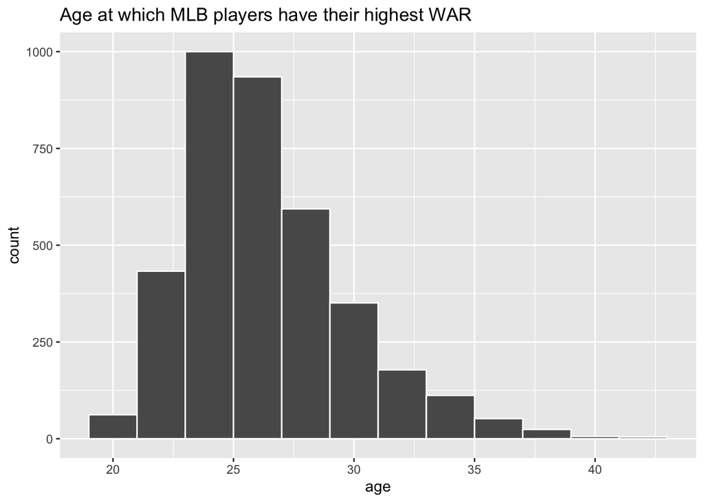

```r
ggplot(prime_age, aes(x = age)) +
  geom_histogram(color = "white", binwidth = 2) +
  labs(title = "Age at which MLB players have their highest WAR")
```

## Exercise 7

> Based on the histogram, it looks like a typical player reaches their prime within a year or two of age 25.

## Exercise 8

```r
prime_age |>
  summarize(mean_prime_age = mean(age),
            med_prime_age = median(age))
```

```
# A tibble: 1 × 2
  mean_prime_age med_prime_age
           <dbl>         <dbl>
1           26.9            26
```

## Exercise 9

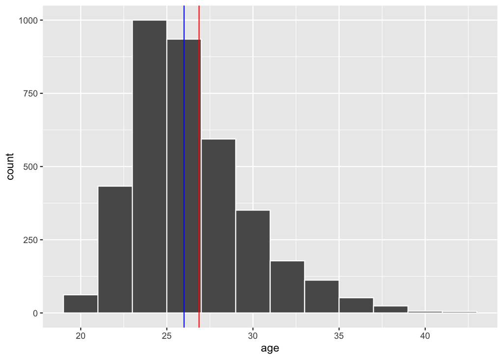

```r
mean_age <- mean(prime_age$age)
median_age <- median(prime_age$age)

ggplot(prime_age, aes(x = age)) +
  geom_histogram(color = "white",
                 binwidth = 2) +
  geom_vline(xintercept = mean_age, color = "red") +
  geom_vline(xintercept = median_age, color = "blue")
```

## Exercise 10

```r
# create new best_war variable
pitcher_stats <- pitcher_stats |>
  group_by(x_mlbamid) |>
  mutate(best_war = max(war)) |>
  ungroup()

# keep only best war year for each player
prime_age_pitchers <- pitcher_stats |>
  filter(war == best_war) |>
  distinct(x_mlbamid, best_war, .keep_all = TRUE)

#check that dimensions match
length(unique(pitcher_stats$x_mlbamid)) == nrow(prime_age_pitchers)
```

```
[1] TRUE
```

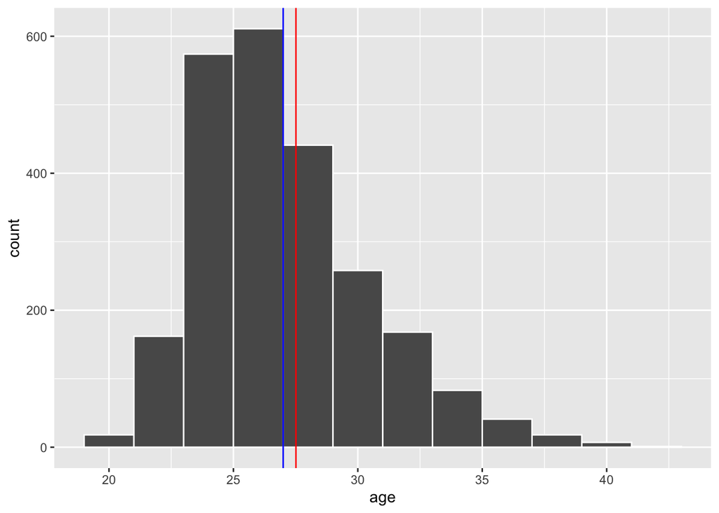

```r
# compute mean, median prime age for pitchers
mean_age_pitchers <- mean(prime_age_pitchers$age)
median_age_pitchers <- median(prime_age_pitchers$age)

ggplot(prime_age_pitchers, aes(x = age)) +
  geom_histogram(color = "white",
                 binwidth = 2) +
  geom_vline(xintercept = mean_age_pitchers, color = "red") +
  geom_vline(xintercept = median_age_pitchers, color = "blue")
```

> The mean prime age for pitchers is 27.5 and the median is 27, which is slightly higher than for all batters.

## Exercise 11

> The prime age of batters and pitchers are similar, but pitchers appear to reach their prime at a slightly older age (27 vs 26). Overall, there is a wide range of prime ages, anywhere from 19 to 42 or 43. However, it would be worth investigating whether there is a smaller age range if you restrict the analysis to only All-Star level players (often WAR of 3+) or MVP-level players (often WAR of 6+). This analysis chose a particular definition of “prime age” - the age at which a MLB player reaches their peak WAR. WAR is only one metric of player performance (though it is intended to be multi-faceted); you could conduct similar analyses with different performance metrics to see if the prime age of 26-27 holds true. Similarly, it would be interesting to investigate whether this result has remained true over time, or if there have been any noteworthly age-related performance trends in the league over time (the MLB is over 100 years old!).